# Mortalidad en UCI por mecanismo de trauma

Cohorte RETRASCORE

2026-11-24

# 1 Lectura de datos

El archivo está en la carpeta superior (`RETRASCORE_VALIDATION`) y usa `;` como separador, por lo que se lee con `read.csv2`.

```r
ruta_csv <- file.path("..", "retrauci_abril_2026.csv")

df <- read.csv2(
  ruta_csv,
  stringsAsFactors = TRUE
)
```

# 2 Selección de pacientes 2020-2025 y mayores de 17 años

Se conservan los pacientes con fecha de ingreso en UCI (`fecha_ingreso_uci`, formato dd/mm/aaaa) entre 2020 y 2025, ambos incluidos, y se eliminan los menores de 18 años. Los pacientes con edad ausente no se eliminan aquí: se contabilizan como pérdida por NA más adelante.

```r
n_inicial <- nrow(df)

df$fecha_ingreso_uci <- as.Date(df$fecha_ingreso_uci, format = "%d/%m/%Y")
df$anyo_ingreso_uci  <- as.integer(format(df$fecha_ingreso_uci, "%Y"))

df <- df[!is.na(df$anyo_ingreso_uci) &
           df$anyo_ingreso_uci >= 2020 &
           df$anyo_ingreso_uci <= 2025, ]
n_2020_2025 <- nrow(df)

edad_num <- suppressWarnings(as.numeric(as.character(df$edad)))
df <- df[is.na(edad_num) | edad_num >= 18, ]

cat("Pacientes iniciales:", n_inicial,
    "\nPacientes 2020-2025:", n_2020_2025,
    "\nMenores de 18 años eliminados:", n_2020_2025 - nrow(df),
    "\nPacientes tras el filtro:", nrow(df), "\n")
```

```
## Pacientes iniciales: 19035
## Pacientes 2020-2025: 9623
## Menores de 18 años eliminados: 214
## Pacientes tras el filtro: 9409
```

# 3 Mortalidad por mecanismo

La mortalidad se define a partir de `evolucion_uci`: `exitus` y `exitus y donacion` cuentan como fallecidos y `alta` como superviviente. Los pacientes con `evolucion_uci` vacío se excluyen del cálculo.

```r
limpiar_texto <- function(x) trimws(tolower(as.character(x)))

evol <- limpiar_texto(df$evolucion_uci)
df$muerte <- ifelse(evol %in% c("exitus", "exitus y donacion"), 1L,
                    ifelse(evol == "alta", 0L, NA_integer_))
df$mecanismo_limpio <- limpiar_texto(df$mecanismo)
df$mecanismo_limpio[df$mecanismo_limpio == ""] <- NA

datos_tabla <- df[!is.na(df$muerte) & !is.na(df$mecanismo_limpio), ]

n_mec      <- tapply(datos_tabla$muerte, datos_tabla$mecanismo_limpio, length)
exitus_mec <- tapply(datos_tabla$muerte, datos_tabla$mecanismo_limpio, sum)

tabla_mecanismo <- data.frame(
  Mecanismo = names(n_mec),
  N = as.integer(n_mec),
  Exitus = as.integer(exitus_mec),
  Mortalidad_pct = round(100 * as.numeric(exitus_mec) / as.numeric(n_mec), 1)
)
tabla_mecanismo <- tabla_mecanismo[order(-tabla_mecanismo$N), ]

fila_total <- data.frame(
  Mecanismo = "TOTAL",
  N = nrow(datos_tabla),
  Exitus = sum(datos_tabla$muerte),
  Mortalidad_pct = round(100 * mean(datos_tabla$muerte), 1)
)
tabla_mecanismo <- rbind(tabla_mecanismo, fila_total)
rownames(tabla_mecanismo) <- NULL

knitr::kable(
  tabla_mecanismo,
  col.names = c("Mecanismo", "n", "Exitus (n)", "Mortalidad (%)"),
  align = c("l", "r", "r", "r")
)
```

| Mecanismo | n | Exitus (n) | Mortalidad (%) |
| --- | --- | --- | --- |
| caida accidental | 2041 | 347 | 17.0 |
| moto | 1483 | 97 | 6.5 |
| precipitacion | 1353 | 155 | 11.5 |
| coche | 1230 | 99 | 8.0 |
| atropello | 696 | 129 | 18.5 |
| bici | 566 | 38 | 6.7 |
| arma blanca | 384 | 15 | 3.9 |
| golpeo con objeto | 342 | 29 | 8.5 |
| otros | 336 | 31 | 9.2 |
| otros vehiculos | 331 | 22 | 6.6 |
| aplastamiento | 206 | 9 | 4.4 |
| desconocido | 153 | 21 | 13.7 |
| arma de fuego | 67 | 18 | 26.9 |
| accidente por zambullida | 53 | 2 | 3.8 |
| explosion | 53 | 11 | 20.8 |
| asta de toro | 44 | 6 | 13.6 |
| vehiculo movilidad unipersonal | 23 | 2 | 8.7 |
| TOTAL | 9361 | 1031 | 11.0 |

```r
cat("Excluidos por evolucion_uci vacío:", sum(is.na(df$muerte)), "\n")
```

```
## Excluidos por evolucion_uci vacío: 46
```

```r
cat("Excluidos por mecanismo vacío:", sum(is.na(df$mecanismo_limpio) & !is.na(df$muerte)), "\n")
```

```
## Excluidos por mecanismo vacío: 2
```

# 4 Mortalidad por intencionalidad

La variable `intencionalidad` se agrupa en tres categorías: **No intencionado** (todas las subcategorías de `no intencional`: tráfico, caída, laboral, deportivo y otras actividades), **Intencionado** (`intencionado : agresion`) y **Autolisis** (`intencionado : autolisis`). Los pacientes con intencionalidad `desconocido` o vacía se excluyen.

```r
int_txt <- limpiar_texto(df$intencionalidad)

df$intencionalidad_3 <- NA_character_
df$intencionalidad_3[grepl("^no intencional", int_txt)]          <- "No intencionado"
df$intencionalidad_3[int_txt == "intencionado : agresion"]       <- "Intencionado"
df$intencionalidad_3[int_txt == "intencionado : autolisis"]      <- "Autolisis"
df$intencionalidad_3 <- factor(
  df$intencionalidad_3,
  levels = c("No intencionado", "Intencionado", "Autolisis")
)

datos_int <- df[!is.na(df$muerte) & !is.na(df$intencionalidad_3), ]

n_int      <- tapply(datos_int$muerte, datos_int$intencionalidad_3, length)
exitus_int <- tapply(datos_int$muerte, datos_int$intencionalidad_3, sum)

tabla_intencionalidad <- data.frame(
  Intencionalidad = names(n_int),
  N = as.integer(n_int),
  Exitus = as.integer(exitus_int),
  Mortalidad_pct = round(100 * as.numeric(exitus_int) / as.numeric(n_int), 1)
)

tabla_intencionalidad <- rbind(
  tabla_intencionalidad,
  data.frame(
    Intencionalidad = "TOTAL",
    N = nrow(datos_int),
    Exitus = sum(datos_int$muerte),
    Mortalidad_pct = round(100 * mean(datos_int$muerte), 1)
  )
)
rownames(tabla_intencionalidad) <- NULL

knitr::kable(
  tabla_intencionalidad,
  col.names = c("Intencionalidad", "n", "Exitus (n)", "Mortalidad (%)"),
  align = c("l", "r", "r", "r")
)
```

| Intencionalidad | n | Exitus (n) | Mortalidad (%) |
| --- | --- | --- | --- |
| No intencionado | 7988 | 870 | 10.9 |
| Intencionado | 630 | 43 | 6.8 |
| Autolisis | 577 | 92 | 15.9 |
| TOTAL | 9195 | 1005 | 10.9 |

```r
cat("Excluidos por evolucion_uci vacío:", sum(is.na(df$muerte)), "\n")
```

```
## Excluidos por evolucion_uci vacío: 46
```

```r
cat("Excluidos por intencionalidad desconocida/vacía:",
    sum(is.na(df$intencionalidad_3) & !is.na(df$muerte)), "\n")
```

```
## Excluidos por intencionalidad desconocida/vacía: 168
```

# 5 Mecanismo de las autólisis

Entre los pacientes con intencionalidad `intencionado : autolisis` se describe el mecanismo de trauma: número de casos, porcentaje sobre el total de autólisis, exitus y mortalidad por mecanismo. Se aplican los mismos criterios de mortalidad (`evolucion_uci`) y limpieza de texto que en las secciones anteriores.

```r
datos_auto <- df[!is.na(df$muerte) &
                   !is.na(df$mecanismo_limpio) &
                   df$intencionalidad_3 %in% "Autolisis", ]

n_auto      <- tapply(datos_auto$muerte, datos_auto$mecanismo_limpio, length)
exitus_auto <- tapply(datos_auto$muerte, datos_auto$mecanismo_limpio, sum)

tabla_auto <- data.frame(
  Mecanismo = names(n_auto),
  N = as.integer(n_auto),
  Pct_autolisis = round(100 * as.numeric(n_auto) / nrow(datos_auto), 1),
  Exitus = as.integer(exitus_auto),
  Mortalidad_pct = round(100 * as.numeric(exitus_auto) / as.numeric(n_auto), 1)
)
tabla_auto <- tabla_auto[order(-tabla_auto$N), ]

tabla_auto <- rbind(
  tabla_auto,
  data.frame(
    Mecanismo = "TOTAL",
    N = nrow(datos_auto),
    Pct_autolisis = 100,
    Exitus = sum(datos_auto$muerte),
    Mortalidad_pct = round(100 * mean(datos_auto$muerte), 1)
  )
)
rownames(tabla_auto) <- NULL

knitr::kable(
  tabla_auto,
  col.names = c("Mecanismo", "n", "% de autólisis", "Exitus (n)", "Mortalidad (%)"),
  align = c("l", "r", "r", "r", "r")
)
```

| Mecanismo | n | % de autólisis | Exitus (n) | Mortalidad (%) |
| --- | --- | --- | --- | --- |
| precipitacion | 396 | 68.6 | 62 | 15.7 |
| arma blanca | 72 | 12.5 | 6 | 8.3 |
| otros | 55 | 9.5 | 12 | 21.8 |
| arma de fuego | 17 | 2.9 | 11 | 64.7 |
| atropello | 17 | 2.9 | 1 | 5.9 |
| coche | 9 | 1.6 | 0 | 0.0 |
| golpeo con objeto | 4 | 0.7 | 0 | 0.0 |
| caida accidental | 3 | 0.5 | 0 | 0.0 |
| accidente por zambullida | 1 | 0.2 | 0 | 0.0 |
| aplastamiento | 1 | 0.2 | 0 | 0.0 |
| desconocido | 1 | 0.2 | 0 | 0.0 |
| otros vehiculos | 1 | 0.2 | 0 | 0.0 |
| TOTAL | 577 | 100.0 | 92 | 15.9 |

```r
auto_todas <- df[df$intencionalidad_3 %in% "Autolisis", ]
cat("Autólisis totales:", nrow(auto_todas), "\n")
```

```
## Autólisis totales: 577
```

```r
cat("Excluidas por evolucion_uci vacío:", sum(is.na(auto_todas$muerte)), "\n")
```

```
## Excluidas por evolucion_uci vacío: 0
```

```r
cat("Excluidas por mecanismo vacío:",
    sum(is.na(auto_todas$mecanismo_limpio) & !is.na(auto_todas$muerte)), "\n")
```

```
## Excluidas por mecanismo vacío: 0
```

# 6 Regiones afectadas y gravedad (MAIS) en el top 5 de mecanismos de autólisis

Para los cinco mecanismos más frecuentes entre las autólisis se describe, por región anatómica, cuántos pacientes tienen lesión y su gravedad según el MAIS regional. La correspondencia entre variables y regiones es: `mais1` = cabeza, `mais2` = extremidad superior, `mais3` = tórax, `mais4` = abdomen, `mais5` = extremidad inferior y `mais6` = externa/térmica. Un MAIS vacío se interpreta como ausencia de lesión en esa región, y un paciente puede contribuir a varias regiones. Se muestran los pacientes con lesión (MAIS ≥ 1), su porcentaje sobre los pacientes del mecanismo, el MAIS medio y mediano entre los lesionados, y el número y porcentaje con lesión grave (MAIS ≥ 3).

```r
regiones_mais <- c(
  "Cabeza"          = "mais1",
  "Ext. superior"   = "mais2",
  "Tórax"           = "mais3",
  "Abdomen"         = "mais4",
  "Ext. inferior"   = "mais5",
  "Externa/térmica" = "mais6"
)

# Top 5 por número de casos (mismos pacientes que la tabla de mecanismos de autólisis)
top5 <- head(tabla_auto$Mecanismo[tabla_auto$Mecanismo != "TOTAL"], 5)

tabla_regiones <- do.call(rbind, lapply(top5, function(m) {
  pac <- datos_auto[datos_auto$mecanismo_limpio == m, ]
  do.call(rbind, lapply(names(regiones_mais), function(r) {
    mais <- suppressWarnings(as.numeric(as.character(pac[[regiones_mais[[r]]]])))
    mais <- mais[!is.na(mais) & mais >= 1]
    data.frame(
      Mecanismo   = m,
      N_mecanismo = nrow(pac),
      Region      = r,
      Con_lesion  = length(mais),
      Pct_lesion  = round(100 * length(mais) / nrow(pac), 1),
      MAIS_medio  = if (length(mais)) round(mean(mais), 2) else NA_real_,
      MAIS_mediana = if (length(mais)) median(mais) else NA_real_,
      MAIS_ge3_n  = sum(mais >= 3),
      MAIS_ge3_pct = round(100 * sum(mais >= 3) / nrow(pac), 1)
    )
  }))
}))
rownames(tabla_regiones) <- NULL

knitr::kable(
  tabla_regiones[, -2],
  col.names = c("Mecanismo", "Región", "Con lesión (n)", "% de pacientes",
                "MAIS medio", "MAIS mediana", "MAIS ≥ 3 (n)", "MAIS ≥ 3 (% de pacientes)"),
  align = c("l", "l", "r", "r", "r", "r", "r", "r")
)
```

| Mecanismo | Región | Con lesión (n) | % de pacientes | MAIS medio | MAIS mediana | MAIS ≥ 3 (n) | MAIS ≥ 3 (% de pacientes) |
| --- | --- | --- | --- | --- | --- | --- | --- |
| precipitacion | Cabeza | 204 | 51.5 | 3.24 | 3.0 | 138 | 34.8 |
| precipitacion | Ext. superior | 109 | 27.5 | 2.09 | 2.0 | 30 | 7.6 |
| precipitacion | Tórax | 296 | 74.7 | 3.22 | 3.0 | 231 | 58.3 |
| precipitacion | Abdomen | 244 | 61.6 | 2.77 | 3.0 | 128 | 32.3 |
| precipitacion | Ext. inferior | 332 | 83.8 | 3.24 | 3.0 | 231 | 58.3 |
| precipitacion | Externa/térmica | 43 | 10.9 | 1.09 | 1.0 | 2 | 0.5 |
| arma blanca | Cabeza | 28 | 38.9 | 2.25 | 2.0 | 9 | 12.5 |
| arma blanca | Ext. superior | 1 | 1.4 | 2.00 | 2.0 | 0 | 0.0 |
| arma blanca | Tórax | 29 | 40.3 | 3.03 | 3.0 | 21 | 29.2 |
| arma blanca | Abdomen | 23 | 31.9 | 2.91 | 3.0 | 18 | 25.0 |
| arma blanca | Ext. inferior | 18 | 25.0 | 1.83 | 2.0 | 5 | 6.9 |
| arma blanca | Externa/térmica | 6 | 8.3 | 1.00 | 1.0 | 0 | 0.0 |
| otros | Cabeza | 38 | 69.1 | 2.50 | 2.0 | 18 | 32.7 |
| otros | Ext. superior | 2 | 3.6 | 2.00 | 2.0 | 1 | 1.8 |
| otros | Tórax | 2 | 3.6 | 2.00 | 2.0 | 0 | 0.0 |
| otros | Abdomen | 1 | 1.8 | 1.00 | 1.0 | 0 | 0.0 |
| otros | Ext. inferior | 2 | 3.6 | 1.50 | 1.5 | 0 | 0.0 |
| otros | Externa/térmica | 28 | 50.9 | 3.82 | 4.0 | 25 | 45.5 |
| arma de fuego | Cabeza | 14 | 82.4 | 4.57 | 5.0 | 13 | 76.5 |
| arma de fuego | Ext. superior | 7 | 41.2 | 3.14 | 4.0 | 5 | 29.4 |
| arma de fuego | Tórax | 2 | 11.8 | 2.00 | 2.0 | 1 | 5.9 |
| arma de fuego | Abdomen | 2 | 11.8 | 2.50 | 2.5 | 1 | 5.9 |
| arma de fuego | Ext. inferior | 2 | 11.8 | 2.00 | 2.0 | 1 | 5.9 |
| arma de fuego | Externa/térmica | 2 | 11.8 | 1.50 | 1.5 | 0 | 0.0 |
| atropello | Cabeza | 9 | 52.9 | 3.33 | 3.0 | 7 | 41.2 |
| atropello | Ext. superior | 5 | 29.4 | 1.80 | 2.0 | 1 | 5.9 |
| atropello | Tórax | 11 | 64.7 | 3.09 | 3.0 | 8 | 47.1 |
| atropello | Abdomen | 7 | 41.2 | 2.57 | 2.0 | 2 | 11.8 |
| atropello | Ext. inferior | 13 | 76.5 | 2.92 | 3.0 | 7 | 41.2 |
| atropello | Externa/térmica | 0 | 0.0 | NA | NA | 0 | 0.0 |

## 6.1 Distribución del MAIS por región

```r
dist_mais <- do.call(rbind, lapply(top5, function(m) {
  pac <- datos_auto[datos_auto$mecanismo_limpio == m, ]
  do.call(rbind, lapply(names(regiones_mais), function(r) {
    mais <- suppressWarnings(as.numeric(as.character(pac[[regiones_mais[[r]]]])))
    fila <- sapply(1:6, function(k) sum(mais == k, na.rm = TRUE))
    data.frame(Mecanismo = m, Region = r, t(fila))
  }))
}))
names(dist_mais)[3:8] <- paste0("MAIS ", 1:6)
rownames(dist_mais) <- NULL

knitr::kable(dist_mais, align = c("l", "l", rep("r", 6)))
```

| Mecanismo | Region | MAIS 1 | MAIS 2 | MAIS 3 | MAIS 4 | MAIS 5 | MAIS 6 |
| --- | --- | --- | --- | --- | --- | --- | --- |
| precipitacion | Cabeza | 12 | 54 | 59 | 36 | 39 | 4 |
| precipitacion | Ext. superior | 24 | 55 | 26 | 4 | 0 | 0 |
| precipitacion | Tórax | 3 | 62 | 132 | 64 | 35 | 0 |
| precipitacion | Abdomen | 6 | 110 | 74 | 41 | 13 | 0 |
| precipitacion | Ext. inferior | 3 | 98 | 97 | 83 | 51 | 0 |
| precipitacion | Externa/térmica | 41 | 0 | 2 | 0 | 0 | 0 |
| arma blanca | Cabeza | 3 | 16 | 8 | 1 | 0 | 0 |
| arma blanca | Ext. superior | 0 | 1 | 0 | 0 | 0 | 0 |
| arma blanca | Tórax | 1 | 7 | 13 | 6 | 2 | 0 |
| arma blanca | Abdomen | 1 | 4 | 14 | 4 | 0 | 0 |
| arma blanca | Ext. inferior | 8 | 5 | 5 | 0 | 0 | 0 |
| arma blanca | Externa/térmica | 6 | 0 | 0 | 0 | 0 | 0 |
| otros | Cabeza | 12 | 8 | 10 | 3 | 5 | 0 |
| otros | Ext. superior | 1 | 0 | 1 | 0 | 0 | 0 |
| otros | Tórax | 0 | 2 | 0 | 0 | 0 | 0 |
| otros | Abdomen | 1 | 0 | 0 | 0 | 0 | 0 |
| otros | Ext. inferior | 1 | 1 | 0 | 0 | 0 | 0 |
| otros | Externa/térmica | 3 | 0 | 8 | 5 | 12 | 0 |
| arma de fuego | Cabeza | 1 | 0 | 1 | 2 | 8 | 2 |
| arma de fuego | Ext. superior | 1 | 1 | 1 | 4 | 0 | 0 |
| arma de fuego | Tórax | 1 | 0 | 1 | 0 | 0 | 0 |
| arma de fuego | Abdomen | 1 | 0 | 0 | 1 | 0 | 0 |
| arma de fuego | Ext. inferior | 1 | 0 | 1 | 0 | 0 | 0 |
| arma de fuego | Externa/térmica | 1 | 1 | 0 | 0 | 0 | 0 |
| atropello | Cabeza | 1 | 1 | 3 | 2 | 2 | 0 |
| atropello | Ext. superior | 2 | 2 | 1 | 0 | 0 | 0 |
| atropello | Tórax | 1 | 2 | 4 | 3 | 1 | 0 |
| atropello | Abdomen | 0 | 5 | 1 | 0 | 1 | 0 |
| atropello | Ext. inferior | 0 | 6 | 3 | 3 | 1 | 0 |
| atropello | Externa/térmica | 0 | 0 | 0 | 0 | 0 | 0 |

## 6.2 Gráficos por región

Paleta: una sola gama azul ordenada de claro a oscuro para el grado MAIS (a más oscuro, más grave), con un hueco del color del fondo entre segmentos.

```r
library(ggplot2)
tinta   <- "#1a1a19"
tinta_2 <- "#5f5e5a"
fondo   <- "#fcfcfb"
cols_mais <- c("MAIS 1" = "#86b6ef", "MAIS 2" = "#5598e7", "MAIS 3" = "#2a78d6",
               "MAIS 4" = "#1c5cab", "MAIS 5" = "#104281", "MAIS 6" = "#0d366b")

tema_mais <- theme_minimal(base_size = 11) +
  theme(
    plot.background  = element_rect(fill = fondo, colour = NA),
    panel.background = element_rect(fill = fondo, colour = NA),
    panel.grid.major.y = element_blank(),
    panel.grid.minor   = element_blank(),
    panel.grid.major.x = element_line(colour = "#e6e5e1", linewidth = 0.3),
    strip.text   = element_text(face = "bold", colour = tinta, hjust = 0),
    axis.text    = element_text(colour = tinta_2),
    axis.title   = element_text(colour = tinta_2),
    plot.title   = element_text(colour = tinta, face = "bold"),
    plot.subtitle = element_text(colour = tinta_2),
    legend.position = "top",
    legend.title = element_blank(),
    legend.text  = element_text(colour = tinta_2)
  )

# English labels, used only inside the figures (tables keep the Spanish names)
region_en <- c(
  "Cabeza"          = "Head",
  "Ext. superior"   = "Upper extremity",
  "Tórax"           = "Thorax",
  "Abdomen"         = "Abdomen",
  "Ext. inferior"   = "Lower extremity",
  "Externa/térmica" = "External / thermal"
)
mecanismo_en <- c(
  "caida accidental"               = "Accidental fall",
  "moto"                           = "Motorcycle",
  "coche"                          = "Car",
  "precipitacion"                  = "Fall from height",
  "atropello"                      = "Pedestrian hit",
  "bici"                           = "Bicycle",
  "arma blanca"                    = "Stabbing (bladed weapon)",
  "golpeo con objeto"              = "Blow with an object",
  "otros"                          = "Other",
  "otros vehiculos"                = "Other vehicles",
  "aplastamiento"                  = "Crush",
  "desconocido"                    = "Unknown",
  "arma de fuego"                  = "Firearm",
  "accidente por zambullida"       = "Diving accident",
  "asta de toro"                   = "Bull goring",
  "explosion"                      = "Explosion",
  "vehiculo movilidad unipersonal" = "Personal mobility vehicle"
)
traducir_mec <- function(x) {
  en <- unname(mecanismo_en[as.character(x)])
  ifelse(is.na(en), as.character(x), en)
}

n_mec_top5 <- setNames(tabla_auto$N[match(top5, tabla_auto$Mecanismo)], top5)
etiqueta_mec <- paste0(traducir_mec(top5), " (n=", n_mec_top5, ")")
names(etiqueta_mec) <- top5
orden_regiones <- names(regiones_mais)
```

### 6.2.1 Distribución del MAIS en cada región

Cada panel es una región anatómica. Cada barra suma 100 % de los pacientes **con lesión en esa región** para ese mecanismo; el número a la derecha es el n de lesionados. Con n pequeño (por ejemplo arma de fuego o atropello) las proporciones son poco estables.

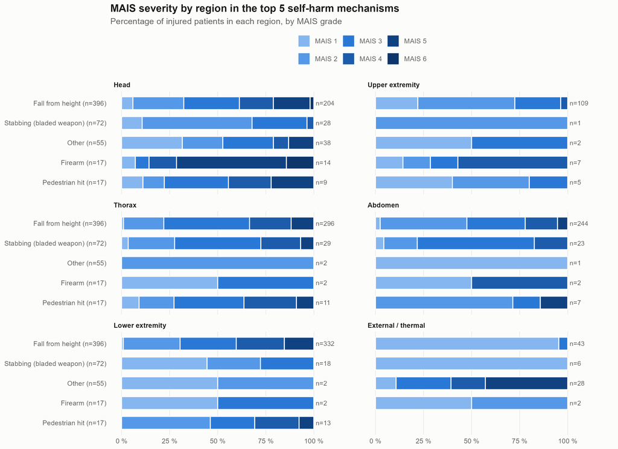

```r
long_mais <- do.call(rbind, lapply(seq_len(nrow(dist_mais)), function(i) {
  data.frame(
    Mecanismo = dist_mais$Mecanismo[i],
    Region    = dist_mais$Region[i],
    MAIS      = paste0("MAIS ", 1:6),
    n         = as.numeric(dist_mais[i, 3:8])
  )
}))
long_mais$tot <- ave(long_mais$n, long_mais$Mecanismo, long_mais$Region, FUN = sum)
long_mais <- long_mais[long_mais$tot > 0, ]
long_mais$pct <- 100 * long_mais$n / long_mais$tot
long_mais$MAIS <- factor(long_mais$MAIS, levels = paste0("MAIS ", 6:1))   # MAIS 1 a la izquierda
long_mais$Region <- factor(long_mais$Region, levels = orden_regiones)
long_mais$Mecanismo <- factor(long_mais$Mecanismo, levels = rev(top5))

totales <- unique(long_mais[, c("Mecanismo", "Region", "tot")])

ggplot(long_mais, aes(x = pct, y = Mecanismo, fill = MAIS)) +
  geom_col(width = 0.65, colour = fondo, linewidth = 0.6) +
  geom_text(data = totales, aes(x = 101, y = Mecanismo, label = paste0("n=", tot)),
            inherit.aes = FALSE, hjust = 0, size = 3, colour = tinta_2) +
  facet_wrap(~ Region, ncol = 2, labeller = labeller(Region = region_en)) +
  scale_fill_manual(values = cols_mais, breaks = paste0("MAIS ", 1:6)) +
  scale_x_continuous(limits = c(0, 118), breaks = seq(0, 100, 25),
                     labels = function(x) paste0(x, " %")) +
  scale_y_discrete(labels = etiqueta_mec) +
  labs(title = "MAIS severity by region in the top 5 self-harm mechanisms",
       subtitle = "Percentage of injured patients in each region, by MAIS grade",
       x = NULL, y = NULL) +
  tema_mais
```

### 6.2.2 Distribución del MAIS en cada mecanismo (regiones en filas)

Misma información que el gráfico anterior pero con los ejes cambiados y **para todos los mecanismos de la cohorte 2020-2025, independientemente de la intencionalidad** (mismos pacientes que la tabla de mortalidad por mecanismo), ordenados por número de casos. Cada panel es un mecanismo y dentro de él hay 6 filas, una por región anatómica. Cada barra suma 100 % de los pacientes **con lesión en esa región**, y el color indica el grado MAIS (a más oscuro, más grave). El número a la derecha es el n de lesionados en esa región; las regiones sin lesionados se muestran vacías con `n=0`. Con n pequeño las proporciones son poco estables.

```r
tabla_mec_orden <- tabla_mecanismo[tabla_mecanismo$Mecanismo != "TOTAL", ]
mecanismos_todos <- tabla_mec_orden$Mecanismo[order(-tabla_mec_orden$N)]
n_mec_todos <- setNames(tabla_mec_orden$N[match(mecanismos_todos, tabla_mec_orden$Mecanismo)],
                        mecanismos_todos)
etiqueta_mec_todos <- paste0(traducir_mec(mecanismos_todos), " (n=", n_mec_todos, ")")

dist_mais_todos <- do.call(rbind, lapply(mecanismos_todos, function(m) {
  pac <- datos_tabla[datos_tabla$mecanismo_limpio == m, ]
  do.call(rbind, lapply(names(regiones_mais), function(r) {
    mais <- suppressWarnings(as.numeric(as.character(pac[[regiones_mais[[r]]]])))
    data.frame(
      Mecanismo = m,
      Region    = r,
      MAIS      = paste0("MAIS ", 1:6),
      n         = sapply(1:6, function(k) sum(mais == k, na.rm = TRUE))
    )
  }))
}))

mec_por_figura <- 4   # 2 x 2 paneles por figura
grupos_mec <- split(mecanismos_todos,
                    ceiling(seq_along(mecanismos_todos) / mec_por_figura))
```

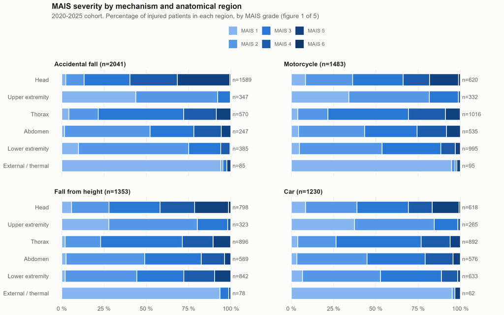

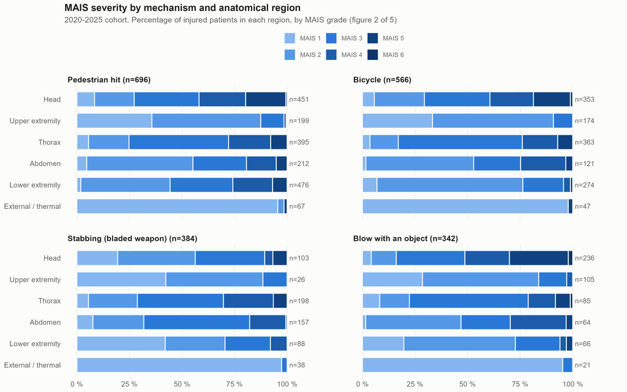

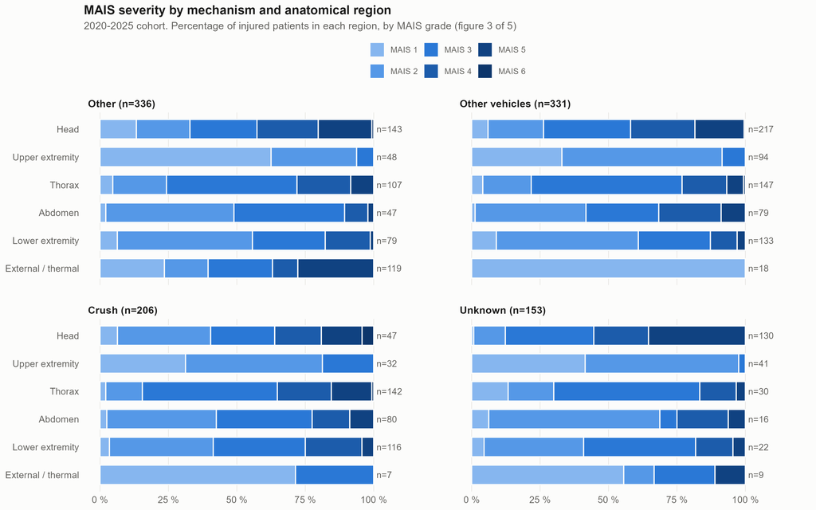

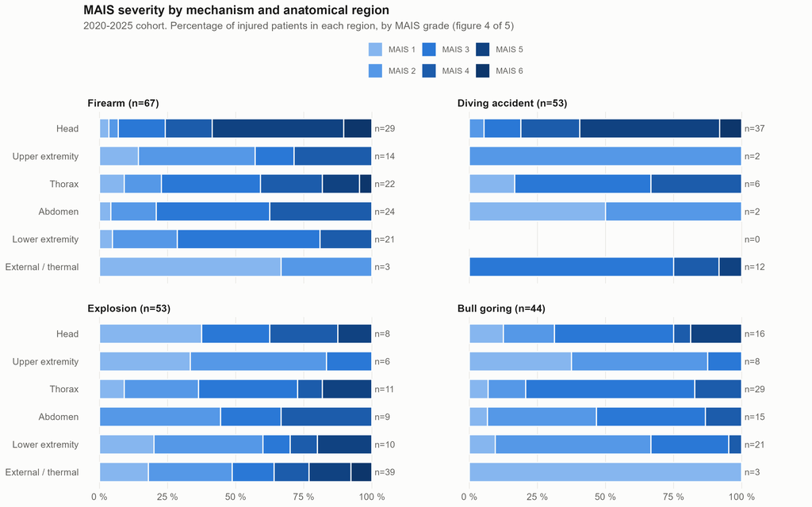

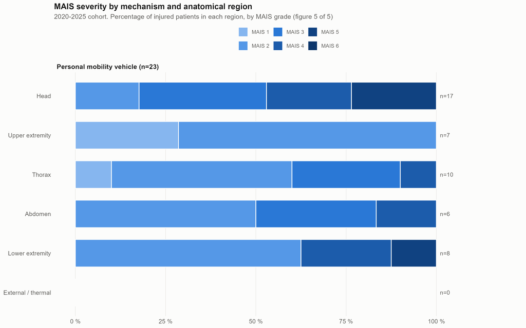

```r
long_mec <- dist_mais_todos
long_mec$tot <- ave(long_mec$n, long_mec$Mecanismo, long_mec$Region, FUN = sum)
long_mec$pct <- ifelse(long_mec$tot > 0, 100 * long_mec$n / long_mec$tot, 0)
long_mec$MAIS <- factor(long_mec$MAIS, levels = paste0("MAIS ", 6:1))    # MAIS 1 a la izquierda
long_mec$Region <- factor(long_mec$Region, levels = rev(orden_regiones))  # Cabeza arriba
long_mec$etiqueta <- etiqueta_mec_todos[match(long_mec$Mecanismo, mecanismos_todos)]

for (g in seq_along(grupos_mec)) {
  datos_g <- long_mec[long_mec$Mecanismo %in% grupos_mec[[g]], ]
  datos_g$etiqueta <- factor(datos_g$etiqueta,
                             levels = etiqueta_mec_todos[match(grupos_mec[[g]], mecanismos_todos)])
  totales_g <- unique(datos_g[, c("etiqueta", "Region", "tot")])

  p <- ggplot(datos_g, aes(x = pct, y = Region, fill = MAIS)) +
    geom_col(width = 0.7, colour = fondo, linewidth = 0.6) +
    geom_text(data = totales_g, aes(x = 101, y = Region, label = paste0("n=", tot)),
              inherit.aes = FALSE, hjust = 0, size = 3.4, colour = tinta_2) +
    facet_wrap(~ etiqueta, ncol = 2, labeller = label_wrap_gen(40)) +
    scale_fill_manual(values = cols_mais, breaks = paste0("MAIS ", 1:6)) +
    scale_x_continuous(limits = c(0, 118), breaks = seq(0, 100, 25),
                       labels = function(x) paste0(x, " %")) +
    scale_y_discrete(drop = FALSE, labels = region_en) +
    labs(title = "MAIS severity by mechanism and anatomical region",
         subtitle = paste0("2020-2025 cohort. Percentage of injured patients in each region, by MAIS grade (figure ",
                           g, " of ", length(grupos_mec), ")"),
         x = NULL, y = NULL) +
    tema_mais +
    theme(axis.text = element_text(size = 10),
          strip.text = element_text(size = 11, face = "bold", colour = tinta, hjust = 0),
          panel.spacing = unit(1.2, "lines"))
  print(p)
}
```

### 6.2.3 Mapa de calor: lesión grave (MAIS ≥ 3)

Resumen en una sola figura. El color es el porcentaje de **todos** los pacientes del mecanismo con MAIS ≥ 3 en esa región; el texto indica el porcentaje y, entre paréntesis, el número de pacientes.

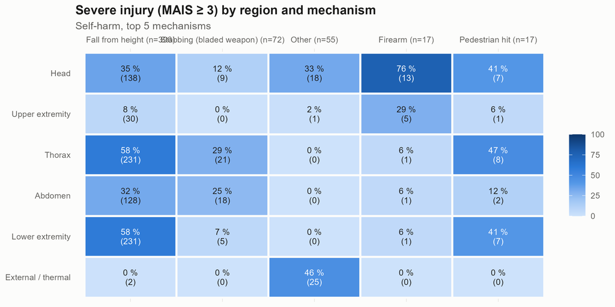

```r
mc <- tabla_regiones
mc$Region <- factor(mc$Region, levels = rev(orden_regiones))
mc$Mecanismo <- factor(mc$Mecanismo, levels = top5)
mc$etiqueta <- paste0(sprintf("%.0f", mc$MAIS_ge3_pct), " %\n(", mc$MAIS_ge3_n, ")")
mc$texto_col <- ifelse(mc$MAIS_ge3_pct >= 35, "#ffffff", tinta)

ggplot(mc, aes(x = Mecanismo, y = Region, fill = MAIS_ge3_pct)) +
  geom_tile(colour = fondo, linewidth = 1) +
  geom_text(aes(label = etiqueta, colour = texto_col), size = 3.2, lineheight = 0.9) +
  scale_colour_identity() +
  scale_fill_gradientn(
    colours = c("#cde2fb", "#9ec5f4", "#5598e7", "#2a78d6", "#1c5cab", "#0d366b"),
    limits = c(0, 100), name = "% with MAIS ≥ 3"
  ) +
  scale_x_discrete(position = "top", labels = function(x) etiqueta_mec[x]) +
  scale_y_discrete(labels = region_en) +
  labs(title = "Severe injury (MAIS ≥ 3) by region and mechanism",
       subtitle = "Self-harm, top 5 mechanisms", x = NULL, y = NULL) +
  tema_mais +
  theme(panel.grid = element_blank(), legend.position = "right")
```

```r
cat("Top 5 de mecanismos (n):\n")
```

```
## Top 5 de mecanismos (n):
```

```r
print(setNames(tabla_auto$N[match(top5, tabla_auto$Mecanismo)], top5))
```

```
## precipitacion   arma blanca         otros arma de fuego     atropello
##           396            72            55            17            17
```

```r
cat("\nNota: atropello y arma de fuego empatan con 17 casos; el orden entre ambos lo decide el orden de la tabla anterior.\n")
```

```
##
## Nota: atropello y arma de fuego empatan con 17 casos; el orden entre ambos lo decide el orden de la tabla anterior.
```

# 7 Pérdida de pacientes por valores ausentes (NA)

Se considera NA una celda vacía o con el texto `NA`/`NAS`. Se muestra la n inicial (pacientes 2020-2025), los menores de 18 años eliminados y la pérdida **secuencial** (pacientes que se van perdiendo al ir aplicando las variables en el orden de la tabla, de modo que un paciente con varios NA solo se cuenta una vez, en la primera variable donde falla). Los traslados a otra UCI/hospital no son NA sino un criterio de exclusión, y se aplican al final.

```r
es_na <- function(x) {
  x <- trimws(as.character(x))
  is.na(x) | x == "" | toupper(x) %in% c("NA", "NAS")
}

variables_na <- c(
  "Edad"                       = "edad",
  "Evolución UCI"              = "evolucion_uci",
  "Mecanismo"                  = "mecanismo",
  "Pupilas al ingreso"         = "pupilas_ingreso",
  "ISS"                        = "iss",
  "Glasgow (GCS total)"        = "gcs_total_introducido",
  "Hemorragia masiva"          = "hemorragia_masiva",
  "Intubación prehospitalaria" = "iot_prehospitalaria",
  "Atención prehospitalaria"   = "atencion_prehospitalaria"
)

# Traslado a otra UCI / hospital antes de la recuperación (destino al alta de UCI)
destinos_traslado <- c("traslado a otra uci", "hospital de origen",
                       "hospital de referencia trauma")

perdidas_na <- function(datos, n_ini, n_menores) {
  restante <- rep(TRUE, nrow(datos))
  filas <- list(
    data.frame(Criterio = "N inicial (2020-2025)", NA_individual = NA_integer_,
               Perdidos = NA_integer_, N_restante = n_ini),
    data.frame(Criterio = "Edad < 18 años", NA_individual = NA_integer_,
               Perdidos = n_menores, N_restante = n_ini - n_menores)
  )
  for (i in seq_along(variables_na)) {
    na_i <- es_na(datos[[variables_na[i]]])
    perdidos_i <- sum(restante & na_i)
    restante <- restante & !na_i
    filas[[length(filas) + 1]] <- data.frame(
      Criterio = names(variables_na)[i],
      NA_individual = sum(na_i),
      Perdidos = perdidos_i,
      N_restante = sum(restante)
    )
  }
  traslado <- limpiar_texto(datos$destino_alta_uci) %in% destinos_traslado
  perdidos_tr <- sum(restante & traslado)
  restante <- restante & !traslado
  filas[[length(filas) + 1]] <- data.frame(
    Criterio = "Traslado a otra UCI/hospital",
    NA_individual = sum(traslado),
    Perdidos = perdidos_tr,
    N_restante = sum(restante)
  )
  tabla <- do.call(rbind, filas)
  tabla$Pct_perdido <- round(100 * tabla$Perdidos / n_ini, 1)
  tabla
}

nombres_col <- c("Criterio", "Perdidos (n)", "N restante", "% perdido sobre N inicial")
```

## 7.1 Tabla (pacientes 2020-2025)

```r
tabla_na <- perdidas_na(df, n_ini = n_2020_2025,
                        n_menores = n_2020_2025 - nrow(df))
tabla_na$NA_individual <- NULL   # se deja solo la columna de pérdidas secuenciales

knitr::kable(tabla_na, col.names = nombres_col,
             align = c("l", "r", "r", "r"))
```

| Criterio | Perdidos (n) | N restante | % perdido sobre N inicial |
| --- | --- | --- | --- |
| N inicial (2020-2025) | NA | 9623 | NA |
| Edad < 18 años | 214 | 9409 | 2.2 |
| Edad | 68 | 9341 | 0.7 |
| Evolución UCI | 46 | 9295 | 0.5 |
| Mecanismo | 2 | 9293 | 0.0 |
| Pupilas al ingreso | 16 | 9277 | 0.2 |
| ISS | 99 | 9178 | 1.0 |
| Glasgow (GCS total) | 549 | 8629 | 5.7 |
| Hemorragia masiva | 8 | 8621 | 0.1 |
| Intubación prehospitalaria | 0 | 8621 | 0.0 |
| Atención prehospitalaria | 0 | 8621 | 0.0 |
| Traslado a otra UCI/hospital | 277 | 8344 | 2.9 |

## 7.2 Detalle de los pacientes perdidos por traslado

Pacientes que llegan a este paso (sin NA en ninguna de las variables anteriores) y se pierden por traslado, desglosados por destino. Se comprueba además su `evolucion_uci` y su `evolucion_hospitalaria` para ver si se conoce el desenlace final.

```r
sin_na <- Reduce(`&`, lapply(variables_na, function(v) !es_na(df[[v]])))
traslados <- df[sin_na & limpiar_texto(df$destino_alta_uci) %in% destinos_traslado, ]

traslados$destino <- limpiar_texto(traslados$destino_alta_uci)
traslados$evol_hosp <- ifelse(es_na(traslados$evolucion_hospitalaria),
                              "sin dato", limpiar_texto(traslados$evolucion_hospitalaria))

tabla_traslados <- as.data.frame(
  table(Destino = traslados$destino,
        `Evolución UCI` = limpiar_texto(traslados$evolucion_uci),
        `Evolución hospitalaria` = traslados$evol_hosp),
  responseName = "n"
)
tabla_traslados <- tabla_traslados[tabla_traslados$n > 0, ]
tabla_traslados <- tabla_traslados[order(-tabla_traslados$n), ]
rownames(tabla_traslados) <- NULL

knitr::kable(tabla_traslados, align = c("l", "l", "l", "r"))
```

| Destino | Evolución.UCI | Evolución.hospitalaria | n |
| --- | --- | --- | --- |
| traslado a otra uci | alta | sin dato | 253 |
| hospital de origen | alta | sin dato | 20 |
| hospital de referencia trauma | alta | sin dato | 4 |

```r
cat("\nTotal perdidos por traslado:", nrow(traslados), "\n")
```

```
##
## Total perdidos por traslado: 277
```